# 1 DC Shock 電擊治療：拯救生命，從正確的電擊與心律反轉術開始

**Defibrillation and Cardioversion Protocol: Emergency and Cardiology Applications**

**整理：余安立 MD；謝慕揚 MD, PhD, FESC** **日期：2025-11-08** **版本：第1.2版**

**目標對象**：急診醫學部、心血管中心醫師、護理師、醫學生、心導管室技術人員

> 基於2024年新版ACLS指引，結合2016年心血管中心DC電擊心律反轉術工作坊資料，適用於急診、病房、加護病房、心導管室

## 1.1 目錄

- 緊急情況與心律反轉術概述
- 緊急情況處理流程
- 脈搏評估與治療策略
- 電擊心律判定與心律反轉術技術
- 電擊與心律反轉術操作程序
- 急救與輔助藥物使用
- 有脈搏心律不整的處理
- 臨床案例討論
- 頑固性心室纖維顫動的除顫策略 — 2022 NEJM
- 特殊情況與團隊協作
- 臨床教育考題
- 總結與實踐要點

## 1.2 緊急情況與心律反轉術概述

### 1.2.1 前言

本講義整合急診醫學與心血管中心的DC電擊治療，基於2024年新版ACLS指引，並參考2016年心血管中心「直流電擊工作坊」資料。旨在為急診科醫師、護理師、醫學生、心臟內科醫師及心導管室技術人員提供標準化操作流程與臨床決策指導。DC電擊（包括除顫與同步電擊）是治療急性心律失常（如心室纖維顫動、心室頻脈、心房顫動）的核心技術，需精準操作以確保安全與療效。

### 1.2.2 目標與意義

- 提供標準化DC電擊與心律反轉術操作流程，也適用於急診與心導管室
- 闡述急救藥物（如腎上腺素、amiodarone）的應用與劑量計算
- 通過案例分析與模擬訓練強化臨床決策與操作能力
- 確保安全操作，降低併發症風險

> **核心原則：**
> - 快速準確的心律判讀與治療決策
> - 高品質胸外按壓與電擊技術
> - 團隊協作與有效溝通
> - 針對老年或衰弱患者的個體化策略

## 1.3 緊急情況處理流程

### 1.3.1 病人倒了！初步評估

當發現病人意識喪失時，醫護人員應立即啟動緊急處理流程，遵循生存鏈（Chain of Survival）原則。

> **緊急處理原則：**
> - 立即確認現場安全
> - 呼叫支援並啟動急救團隊
> - 快速評估患者意識和生命徵象
> - 遵循2024年ACLS指引

### 1.3.2 ACLS 評估流程

| 評估步驟 | 處理原則 |
| --- | --- |
| 環境安全確認 | 確保現場無電擊、火災、化學等危險；移除患者身上金屬物品；清理呼吸道分泌物 |
| 意識評估 | 拍打肩膀大聲呼喊；評估對聲音、疼痛的反應；檢查瞳孔反應 |
| 呼吸評估 | 觀察胸廓起伏；聽診呼吸音；評估呼吸頻率和品質 |
| 脈搏檢查 | 觸診頸動脈脈搏（成人）；檢查時間不超過10秒；同時評估脈搏強度和規律性 |

## 1.4 脈搏評估與治療策略

### 1.4.1 無脈搏情況處理

> **無脈搏時的治療原則：「先壓再說，別廢話」。** 立即開始高品質胸外按壓（深度5-6公分，完全回彈，減少中斷），同時準備除顫器進行心律分析。

### 1.4.2 有脈搏情況評估

| 評估項目 | 評估內容 |
| --- | --- |
| 意識狀態 | Glasgow Coma Scale (GCS) 評分；對聲音、疼痛刺激的反應；自發性語言和動作能力 |
| 生命徵象 | 血壓：收縮壓 >90 mmHg為基本目標；心率：評估是否過快或過慢；呼吸：頻率、深度、血氧飽和度；體溫：排除發燒或低體溫 |
| 血流灌注評估 | 末梢循環：毛細血管再充盈時間；皮膚溫度和顏色；尿液輸出量（若有導尿管） |

## 1.5 電擊心律判定與心律反轉術技術

### 1.5.1 心律分析的基本原則

> **心律判定的兩大要素：**
> - **規律性**：心律是否規則，RR間距是否一致
> - **QRS波寬度**：窄QRS（<120毫秒）或寬QRS（≥120毫秒）

### 1.5.2 可電擊心律（Shockable Rhythms）

| 心律類型 | 特徵 | 處理原則 |
| --- | --- | --- |
| 心室纖維顫動 (VF) | 不規律、寬QRS | 立即除顫，能量200J起跳；不需同步，立即放電；除顫後立即CPR 2分鐘 |
| 心室頻脈 (VT) | 規律、寬QRS | 無脈搏VT：立即除顫；有脈搏VT：考慮同步電擊；能量建議200J起跳 |
| 尖端扭轉型VT (TdP) | 不規律、寬QRS | 立即除顫200J；考慮magnesium sulfate治療；尋找並糾正誘發因素 |

> **Pearl**: 若已知確定為 low LVEF (LVEF < 35%)，應考慮早期啟動進階治療策略。

### 1.5.3 不可電擊心律（Non-Shockable Rhythms）

| 心律類型 | 特徵 | 處理原則 |
| --- | --- | --- |
| 心室停止 (Asystole) | 無心電活動 | 持續高品質CPR；Epinephrine 1mg q3min；尋找可逆轉原因（H’s and T’s） |
| 無脈性電氣活動 (PEA) | 有心電波但無脈搏 | 持續高品質CPR；Epinephrine 1mg q3min；積極尋找並處理根本原因 |

### 1.5.4 同步電擊心律反轉術適應症與禁忌症

| 類別 | 詳細內容 |
| --- | --- |
| 適應症 | 持續性或陣發性心房顫動/撲動（藥物無效或不耐受）；血流動力學不穩的室性心動過速；急性心律失常伴症狀（如胸痛、暈厥） |
| 禁忌症 | 未經抗凝治療且無食道超音波確認的AF（>48小時）；嚴重電解質紊亂（如低鉀血症）；患者拒絕或無法耐受麻醉；無明確心律失常證據 |

## 1.6 電擊與心律反轉術操作程序

### 1.6.1 除顫器設備準備

| 操作步驟 | 詳細說明 |
| --- | --- |
| 能量設定 | 雙相波除顫器：200J起跳（除顫）；100-200J（同步心律反轉術）；後續電擊：200-300-360J遞增；兒童：2-4 J/kg，最高不超過成人劑量 |
| 電極貼片放置 | 右上：右鎖骨下方；左下：左乳頭外下方，避開乳房組織；前後位（心導管室常用）或胸骨旁位；確保貼片完全貼合，無氣泡，間距至少8公分 |
| 同步與非同步選擇 | 有脈搏心律不整：選擇同步模式，確認R波標記；無脈搏VF/VT：非同步模式；緊急情況優先非同步電擊 |

### 1.6.2 電擊執行流程

> **電擊執行五步驟：**
> 1. **調能量**：設定適當的電擊能量（除顫200J，心律反轉術100-200J）
> 2. **選同步**：根據心律選擇同步或非同步模式
> 3. **塗膠充電**：確保電極接觸良好並充電
> 4. **清場**：大聲宣布「清場」，確認無人接觸患者
> 5. **放電**：雙手同時按壓放電鈕

### 1.6.3 術前與術後管理（同步心律反轉術）

| 階段 | 說明 |
| --- | --- |
| 術前評估 | 確認適應症（如持續性AF、血流動力學不穩的室速）；評估抗凝治療狀態（至少3週抗凝或經食道超音波排除左心房血栓）；檢查電解質平衡（如鉀、鎂） |
| 麻醉管理 | 全身麻醉或丙泊酚鎮靜；監測血氧、心電圖及血壓；老年患者劑量減半 |
| 術後監測 | 持續監測心律、血壓及意識狀態；評估皮膚燒傷或不適；繼續抗凝治療至少4週 |

同步電擊的關鍵是確保電擊與R波同步，避免T波期間電擊誘發心室纖維顫動。老年患者對電擊和麻醉更敏感，需謹慎選擇初始能量並密切監測。

## 1.7 急救與輔助藥物使用

### 1.7.1 Epinephrine（腎上腺素）

> **Epinephrine使用指引：**
> - **劑量**：1mg靜脈注射或骨內注射
> - **頻率**：每3-5分鐘重複給予
> - **濃度**：1:10,000 (0.1mg/mL)
> - **適應症**：心臟驟停或嚴重低血壓
> - **注意事項**：給藥後立即沖洗管路，確保藥物進入循環

### 1.7.2 Amiodarone（商品名: Cordarone）

> **Amiodarone使用指引：**
> - **負荷劑量**：300mg靜脈推注，可追加150mg
> - **維持劑量**：1mg/min輸注6小時，然後0.5mg/min
> - **調配方式**：900mg（6安瓿）加入D5W 500mL
> - **輸注速度**：初期34mL/hr，後期17mL/hr
> - **注意事項**：
>   - 使用非PVC輸液管避免藥物吸附
>   - 監測低血壓、QT間期延長、肝功能異常
>   - 長期使用評估甲狀腺及肺毒性風險
>   - 老年患者劑量謹慎調整

### 1.7.3 劑量計算示例

- **Amiodarone滴速計算**：
  - 濃度 = 900mg / 500mL = 1.8mg/mL
  - 初始滴速 = 1mg/min / 1.8mg/mL x 60min/hr ≈ 33.33mL/hr ≈ **34mL/hr**
  - 維持滴速 = 0.5mg/min / 1.8mg/mL x 60min/hr ≈ 16.67mL/hr ≈ **17mL/hr**
- **劑量減半示例**：如初始300mg，減半為150mg。

精確計算amiodarone滴速及電擊能量對於療效與安全性至關重要。臨床醫師應使用標準化計算工具並複核劑量，特別在老年或衰弱患者中。

## 1.8 有脈搏心律不整的處理

### 1.8.1 不穩定心律不整的判定

| 不穩定表現 | 評估要點 |
| --- | --- |
| 意識改變 | 意識混亂、嗜睡或昏迷；對刺激反應遲鈍；Glasgow Coma Scale下降 |
| 胸痛或呼吸困難 | 急性胸痛，懷疑心肌缺血；急性肺水腫症狀；血氧飽和度下降 |
| 血壓過低 | 收縮壓 <90 mmHg；平均動脈壓 <65 mmHg；末梢灌注不良 |
| 心衰症狀 | 急性心衰惡化；肺水腫、下肢水腫；頸靜脈怒張 |

### 1.8.2 同步電擊的適應症與操作

| 心律類型 | 建議能量與處理 |
| --- | --- |
| 心房纖維顫動 | 初始能量：100-200J（雙相波）；若無效：遞增至200-300J；考慮藥物前處理（如Diltiazem） |
| 心房撲動 | 初始能量：50-100J；成功率較高，通常一次即可成功；注意復發可能性 |
| 室上性頻脈 | 初始能量：50-100J；先嘗試Valsalva動作或Adenosine；電擊前可考慮鎮靜 |
| 心室頻脈（有脈搏） | 初始能量：100J；遞增：100-200-300J；高度懷疑隨時可能轉為VF |

## 1.9 臨床案例討論

### 1.9.1 案例1：急性心房顫動

> **病例**：75歲男性，因心悸及胸悶入院，心電圖顯示心房顫動，心率150次/分，血壓100/60 mmHg。無衰弱，腎功能正常，已抗凝4週。

> **治療決策與依據：**
> - **DC電擊心律反轉術**：初始能量100J，同步模式。若無效，增至200J。
> - **Amiodarone輔助**：150mg靜脈推注，若電擊後心律不穩，給予1mg/min滴注6小時。
> - **監測**：術後監測心律、血壓及QT間期，繼續抗凝4週。
> - **依據**：快速心室率及症狀需緊急心律反轉術，amiodarone可穩定心律。

### 1.9.2 案例2：老年衰弱患者

> **病例**：82歲女性，Fried衰弱指數4分，因反覆心悸入院，心電圖顯示心房撲動，心率130次/分，血壓90/50 mmHg，伴輕度心衰。

> **治療決策與依據：**
> - **初始藥物治療**：amiodarone 150mg靜脈推注，隨後0.5mg/min滴注，觀察心律控制。
> - **DC電擊心律反轉術**：若藥物無效，考慮低能量（50-100J）電擊，注意麻醉劑量減半。
> - **監測**：密切監測低血壓及心衰惡化，確保電解質平衡。
> - **依據**：衰弱患者對電擊及麻醉敏感，優先藥物治療，必要時謹慎心律反轉術。

## 1.10 頑固性心室纖維顫動的除顫策略 — 2022 NEJM

### 1.10.1 研究背景

根據2022年《新英格蘭醫學期刊》發表的研究（[Cheskes et al, NEJM Nov 6, 2022](https://www.nejm.org/doi/full/10.1056/NEJMoa2207304)），針對頑固性心室纖維顫動（Refractory Ventricular Fibrillation, RVF）的除顫策略進行比較，探討標準除顫（Standard Defibrillation）、雙序除顫（Double Sequential Defibrillation, DSD）及向量改變除顫（Vector Change Defibrillation, VC）的效果。本研究在院外心臟驟停（Out-of-Hospital Cardiac Arrest, OHCA）情境中進行，旨在提升RVF患者的存活率。

> **研究重點：**
> - 頑固性心室纖維顫動定義為：初始心律為心室纖維顫動或無脈性心室頻脈，經三次標準除顫後仍持續存在。
> - 比較三種除顫策略：標準（單組電極貼片）、DSD（兩組電極貼片近乎同時放電）、VC（改變電極貼片位置至前後位）。
> - 主要結果為存活至出院，次要結果包括心室纖維顫動終止、自主循環恢復（ROSC）及神經功能預後。

### 1.10.2 試驗設計與方法

研究為隨機對照試驗，於院外環境由救護人員執行，納入RVF患者（排除溺水、低溫、藥物過量等原因）。三組策略如下：

| 除顫策略 | 操作說明 |
| --- | --- |
| 標準除顫 | 使用單組電極貼片，放置於右鎖骨下及左乳頭外下方。能量設定為200J（雙相波），若無效遞增至360J。每次除顫後進行2分鐘CPR。 |
| 雙序除顫（DSD） | 使用兩台除顫器，第二組電極貼片置於前後位（胸骨前及背部）。兩台除顫器近乎同時（間隔<1秒）放電，能量各200J。於第三次標準除顫失敗後啟用。 |
| 向量改變除顫（VC） | 將電極貼片位置從標準位置改為前後位（胸骨前及背部）。使用單台除顫器，能量200-360J。於第三次標準除顫失敗後啟用。 |

### 1.10.3 除顫策略比較

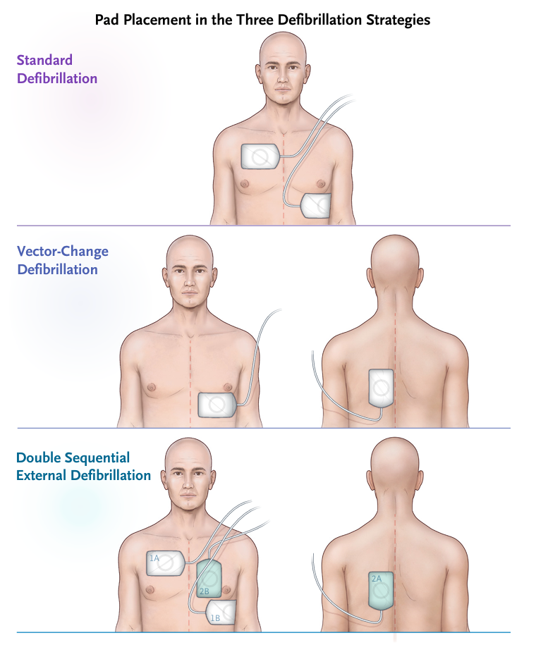

標準除顫作法，vector-change=向量改變除顫，DSD=雙序除顫

DSD與VC需額外設備或貼片位置調整，適合都市環境（第二台除顫器較易取得）。操作時需確保「清場」安全，並避免同時放電損壞設備。

### 1.10.4 試驗結果

研究納入約930名患者（每組約310人），主要與次要結果如下：

| 結果指標 | 標準除顫 | DSD | VC |
| --- | --- | --- | --- |
| 存活至出院 | 13.3% | 21.7% | 26.7% |
| 心室纖維顫動終止 | 79.3% | 84.1% | 82.4% |
| 自主循環恢復（ROSC） | 30.4% | 39.3% | 44.0% |
| 良好神經功能（mRS≤2） | 8.3% | 14.7% | 16.4% |

> **結果分析：**
> - DSD與VC相較於標準除顫，存活至出院率顯著提高（DSD：RR 1.63，95% CI 1.11-2.40；VC：RR 2.01，95% CI 1.40-2.88）。
> - VC在ROSC與神經功能預後上表現最佳，但其優勢需謹慎解讀（脆弱性指數為1）。
> - 所有策略均需高品質CPR配合，且結果受COVID-19疫情影響（如試驗規模縮減）。

### 1.10.5 臨床應用與限制

本研究提示DSD與VC可作為頑固性心室纖維顫動的替代策略，尤其在多次標準除顫失敗後。臨床應用建議如下：

> **臨床應用要點：**
> - 對於RVF患者，於三次標準除顫（200-360J）失敗後，考慮DSD或VC。
> - DSD需兩台除顫器，確保操作人員熟悉雙機操作與安全流程。
> - VC操作較簡單，適合設備有限環境，但需正確放置前後位電極。
> - 持續高品質CPR與腎上腺素使用（1mg q3-5min）為關鍵。

研究限制包括：COVID-19疫情導致樣本數不足，試驗於都市環境進行（可能不適用偏遠地區），未收集種族或住院治療資料。臨床醫師應根據設備可用性與團隊訓練程度選擇策略，並諮詢資深醫師。

## 1.11 特殊情況與團隊協作

### 1.11.1 諮詢當值醫師的時機

> **建議諮詢情況：**
> - 心律判讀有疑慮時
> - 何時應該直接考慮啟動 ECMO? Ans: 最近一年內支架術後，CABG術後，或已知LVEF差的病患，應第一時間詢問是否通知ECMO team (先call CVS VS).
> - 患者對標準治療反應不佳
> - 存在特殊合併症（如懷孕、植入式裝置）
> - 家屬對治療方向有重大關切
> - 考慮終止急救時

### 1.11.2 團隊溝通與安全考量

| 溝通要點 | 具體作法 |
| --- | --- |
| 角色分工 | 明確指定團隊領導者；分配按壓、通氣、用藥、記錄等任務；定期輪換避免疲勞 |
| 資訊傳遞 | 大聲清楚地報告心律變化；確認藥物劑量和給藥時間；即時更新生命徵象 |
| 安全宣告 | 電擊前大聲「清場」；確認所有人員遠離患者；檢查氧氣是否關閉 |

## 1.12 臨床教育考題

### 1.12.1 考題設計

1. DC電擊心律反轉術的主要適應症是什麼？
2. 同步電擊的目的是什麼？如何確保正確操作？
3. Amiodarone 靜脈負荷劑量的標準劑量是多少？
4. 如何計算amiodarone 1mg/min的滴速（900mg溶於500mL D5W）？
5. 老年患者進行DC電擊心律反轉術時應注意哪些特殊考量？
6. DC電擊心律反轉術的常見併發症有哪些？如何預防？
7. 腎上腺素在何種情況下使用？
8. 若初始100J電擊失敗，下一步應選擇的能量是多少？
9. Amiodarone 長期使用的潛在副作用有哪些？
10. 如何評估患者是否適合DC電擊心律反轉術？

### 1.12.2 考題詳解

1. **答案**：持續性心房顫動/撲動、血流動力學不穩的室性心動過速、急性症狀性心律失常。 **詳解**：需確認抗凝狀態與適應症。
2. **答案**：防止誘發室顫，確保電擊與R波同步。 **詳解**：除顫器需開啟同步模式，確認R波標記。
3. **答案**：150-300mg靜脈推注。 **詳解**：依患者狀況選擇劑量。
4. **答案**：約34mL/hr。 **詳解**：濃度1.8mg/mL，1mg/min需33.33mL/hr，約34mL/hr。
5. **答案**：衰弱、共病、低耐受性，需低能量及減量麻醉。 **詳解**：老年患者對電擊敏感，需密切監測。
6. **答案**：皮膚燒傷、低血壓、心律惡化；預防包括正確電極放置及監測。 **詳解**：標準指南強調這些風險。
7. **答案**：心臟驟停或嚴重低血壓。 **詳解**：用於電擊後血流動力學不穩。
8. **答案**：200J。 **詳解**：逐步增加能量至360J。
9. **答案**：甲狀腺異常、肺毒性、肝損傷、QT延長。 **詳解**：長期監測必要。
10. **答案**：確認適應症、抗凝狀態、電解質平衡及麻醉耐受性。 **詳解**：全面術前評估降低風險。

## 1.13 總結與實踐要點

### 1.13.1 核心要點回顧

> **關鍵成功因素：**
> - 快速準確的心律判讀
> - 適當的能量選擇和電擊時機
> - 高品質的胸外按壓配合
> - 有效的團隊協作和溝通
> - 針對老年或衰弱患者的個體化策略

### 1.13.2 持續改進建議

- 參與ACLS認證訓練和更新
- 定期進行模擬急救演練
- 檢討實際案例，分析改進空間
- 熟悉最新急救與心律反轉術指引
- 加強團隊溝通與操作技巧訓練

## 1.14 修正紀錄

- Version 1.2: 2025-11-08 邀請余安立醫師編修，修正復律，改為心律反轉術。